# Encontros relâmpagos

João Victor Mafra, Jobson Lucas e Gileade Kelvin

12 de outubro de 2016

# OS DADOS

Dados amostrais de 20 encontros relâmpagos. Uma pessoa avalia a pessoa com a qual se encontrou sob diferentes aspectos (fornecendo notas de 0 a 10) e no fim, atribui uma nota a ela no geral de 0 a 10. Sobre esses aspectos, focaremos no quão a pessoa achou a outra atraente e o quão a pessoa achou a outra divertida, como o objetivo de verificar se essa duas variáveis podem explicar uma variável dependente, que nesse caso é a nota geral.

```r
amostra
```

```
##    Atraente Divertido Nota
## 1         8         7  8.0
## 2         5         7  6.5
## 3         6         5  7.0
## 4         6         4  6.0
## 5         5         4  4.0
## 6         6         5  6.0
## 7         7         8  7.0
## 8         6         7  6.0
## 9         5         8  8.0
## 10        4         5  3.0
## 11        4         4  2.0
## 12        6         5  6.0
## 13        8         8  8.0
## 14        3         5  5.0
## 15        3         5  5.0
## 16        8         6  8.0
## 17        6         7  8.0
## 18        4         6  5.0
## 19        5         4  5.0
## 20        3         3  3.0
```

# GRÁFICO DE DISPERSÃO ENTRE X1 (Avaliação para beleza da pessoa) e Y (Nota final)

Abaixo temos o gráfico de dispersão entre as duas variáveis, o coeficiente de correlação linear entre elas e o teste de hipótese para essa correlação. A região crítica está entre 0.48 e 0.90, que contém a correlação observada (0.76), logo a hipótese nula é rejeitada em favor da alternativa, indicando que a correlação é diferente de 0. Também podemos verificar isso usando p-valor, que é muito pequeno.

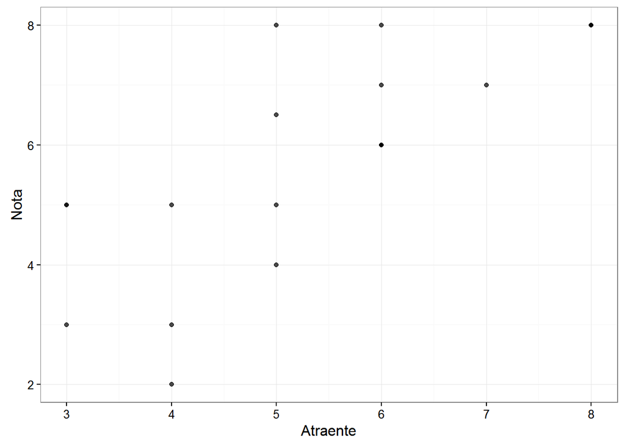

```r
ggplot(amostra, aes(x = Atraente, y = Nota)) +
  geom_point(alpha = 0.7)
```

```r
cor(amostra$Atraente, amostra$Nota)
```

```
## [1] 0.7608506
```

```r
cor.test(amostra$Atraente, amostra$Nota)
```

```
##
##  Pearson's product-moment correlation
##
## data:  amostra$Atraente and amostra$Nota
## t = 4.9744, df = 18, p-value = 9.814e-05
## alternative hypothesis: true correlation is not equal to 0
## 95 percent confidence interval:
##  0.4799127 0.9002606
## sample estimates:
##       cor
## 0.7608506
```

# GRÁFICO DE DISPERSÃO ENTRE X2 (Avaliação para o quão a pessoa é divertida) e Y (Nota final)

Abaixo temos o gráfico de dispersão entre as duas variáveis, o coeficiente de correlação linear entre elas e o teste de hipótese para essa correlação. A região crítica está entre 0.47 e 0.90, que contém a correlação observada (0.75), logo a hipótese nula é rejeitada em favor da alternativa, indicando que a correlação é diferente de 0. Também podemos verificar isso usando p-valor, que é muito pequeno.

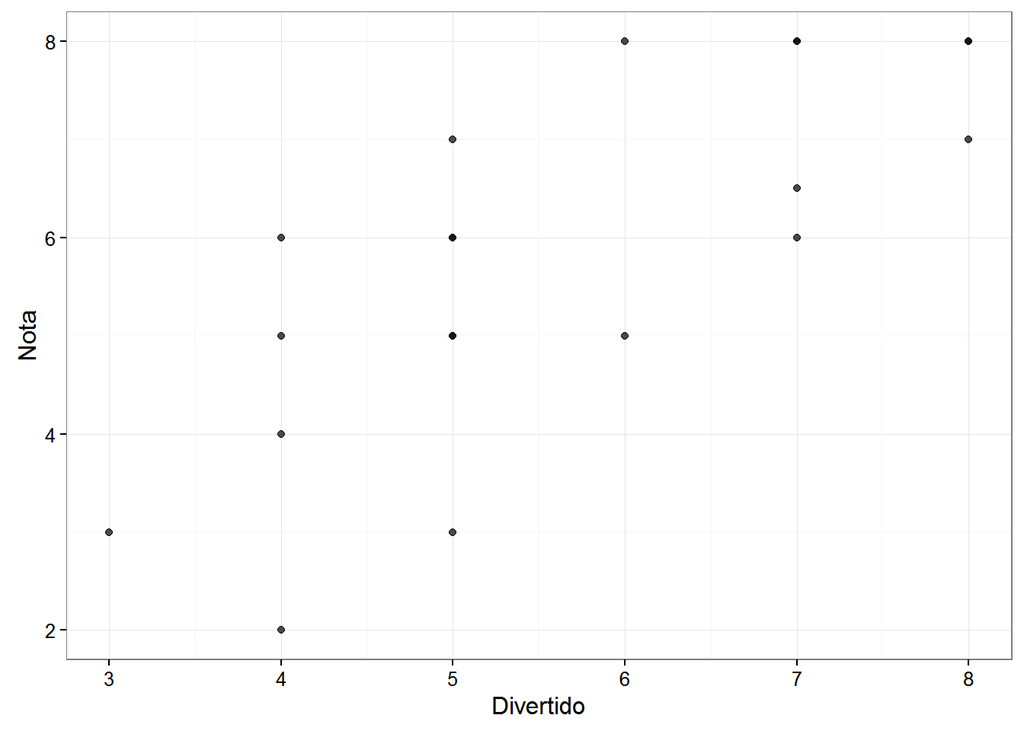

```r
ggplot(amostra, aes(x = Divertido, y = Nota)) +
  geom_point(alpha = 0.7)
```

```r
cor(amostra$Divertido, amostra$Nota)
```

```
## [1] 0.7564063
```

```r
cor.test(amostra$Divertido, amostra$Nota)
```

```
##
##  Pearson's product-moment correlation
##
## data:  amostra$Divertido and amostra$Nota
## t = 4.9062, df = 18, p-value = 0.0001138
## alternative hypothesis: true correlation is not equal to 0
## 95 percent confidence interval:
##  0.4718136 0.8982574
## sample estimates:
##       cor
## 0.7564063
```

Como pudemos ver, em ambos os casos temos um forte suspeita de relação linear entre as variáveis

# REGRESSÃO LINEAR MÚLTIPLA

A seguir, a matriz das notas gerais(Y).

```r
y = matrix(c(8,6.5,7,6,4 ,6 ,7, 6, 8, 3, 2, 6, 8, 5 ,5 ,8, 8 ,5, 5, 3))
y
```

```
##       [,1]
##  [1,]  8.0
##  [2,]  6.5
##  [3,]  7.0
##  [4,]  6.0
##  [5,]  4.0
##  [6,]  6.0
##  [7,]  7.0
##  [8,]  6.0
##  [9,]  8.0
## [10,]  3.0
## [11,]  2.0
## [12,]  6.0
## [13,]  8.0
## [14,]  5.0
## [15,]  5.0
## [16,]  8.0
## [17,]  8.0
## [18,]  5.0
## [19,]  5.0
## [20,]  3.0
```

Aqui temos a matriz das notas para o quão a pessoa é atraente(X1) e das notas para o quão a pessoa é divertida(X2) resultando na matriz X.

```r
X = matrix(c(1, 8, 7, 1, 5, 7 ,1, 6, 5, 1, 6, 4, 1, 5, 4, 1, 6, 5, 1, 7, 8 ,1, 6, 7, 1, 5, 8, 1, 4, 5, 1, 4, 4, 1, 6, 5, 1, 8, 8, 1, 3, 5, 1, 3, 5, 1, 8, 6, 1 ,6, 7 ,1, 4, 6, 1, 5, 4, 1, 3, 3),20,3,byrow=T)
X
```

```
##       [,1] [,2] [,3]
##  [1,]    1    8    7
##  [2,]    1    5    7
##  [3,]    1    6    5
##  [4,]    1    6    4
##  [5,]    1    5    4
##  [6,]    1    6    5
##  [7,]    1    7    8
##  [8,]    1    6    7
##  [9,]    1    5    8
## [10,]    1    4    5
## [11,]    1    4    4
## [12,]    1    6    5
## [13,]    1    8    8
## [14,]    1    3    5
## [15,]    1    3    5
## [16,]    1    8    6
## [17,]    1    6    7
## [18,]    1    4    6
## [19,]    1    5    4
## [20,]    1    3    3
```

Adiante, temos a matriz transposta da matriz anterior X.

```r
Xt = t(X)
Xt
```

```
##      [,1] [,2] [,3] [,4] [,5] [,6] [,7] [,8] [,9] [,10] [,11] [,12] [,13]
## [1,]    1    1    1    1    1    1    1    1    1     1     1     1     1
## [2,]    8    5    6    6    5    6    7    6    5     4     4     6     8
## [3,]    7    7    5    4    4    5    8    7    8     5     4     5     8
##      [,14] [,15] [,16] [,17] [,18] [,19] [,20]
## [1,]     1     1     1     1     1     1     1
## [2,]     3     3     8     6     4     5     3
## [3,]     5     5     6     7     6     4     3
```

Já aqui temos a matriz transposta acima multiplicada pela matriz original X.

```r
XtX = Xt %*% X
XtX
```

```
##      [,1] [,2] [,3]
## [1,]   20  108  113
## [2,]  108  632  636
## [3,]  113  636  683
```

Temos também a matriz inversa do produto acima.

```r
InvXtX = solve(XtX)
InvXtX
```

```
##             [,1]        [,2]        [,3]
## [1,]  0.90029170 -0.06284805 -0.09042694
## [2,] -0.06284805  0.02953461 -0.01710422
## [3,] -0.09042694 -0.01710422  0.03235216
```

Temos ainda o produto da matriz transposta X pela matriz das notas Y.

```r
Xty = Xt %*% y
Xty
```

```
##       [,1]
## [1,] 116.5
## [2,] 671.5
## [3,] 698.5
```

Por conseguinte, obtemos o estimador Beta através do produto da matriz inversa encontrada anteriormente por Xty(transposta de X multiplicada por Y). O b0 estimado é -0.48, o b1 0.56 e o b2 0.57.

```r
Beta.est = InvXtX %*% Xty
Beta.est
```

```
##            [,1]
## [1,] -0.4817025
## [2,]  0.5633950
## [3,]  0.5777645
```

Ademais, iremos obter os valores estimados de y.

```r
y.est = X%*%Beta.est
y.est
```

```
##           [,1]
##  [1,] 8.069809
##  [2,] 6.379624
##  [3,] 5.787490
##  [4,] 5.209726
##  [5,] 4.646331
##  [6,] 5.787490
##  [7,] 8.084179
##  [8,] 6.943019
##  [9,] 6.957389
## [10,] 4.660700
## [11,] 4.082936
## [12,] 5.787490
## [13,] 8.647574
## [14,] 4.097305
## [15,] 4.097305
## [16,] 7.492045
## [17,] 6.943019
## [18,] 5.238465
## [19,] 4.646331
## [20,] 2.941776
```

Aqui obteremos a Soma de Quadrados de Regressão(SQreg).

```r
mean_y = mean(y)
length_y = nrow(y)
GL_reg = 2
GL_res = length_y - GL_reg - 1
GL_tot = length_y - 1

Beta_t_Xty = t(Beta.est) %*% Xty
Beta_t_Xty_elem = Beta_t_Xty[1,1]
SQreg = Beta_t_Xty_elem - length_y*(mean_y)^2
SQreg
```

```
## [1] 47.15741
```

Além disso, obtemos Soma de Quadrados de Resíduos(SQres).

```r
yty = t(y)%*%y
yty_elem = yty[1,1]
SQres = yty_elem - Beta_t_Xty_elem
SQres
```

```
## [1] 16.48009
```

Por fim, no quesito Soma de Quadrados, temos Soma de Quadrados Total(SQtot).

```r
SQtot = yty_elem - length_y*(mean_y)^2
SQtot
```

```
## [1] 63.6375
```

Posteriormente, temos o Quadrado Médio das Regressões(QMreg).

```r
QMreg = SQreg / GL_reg
QMreg
```

```
## [1] 23.57871
```

Além do mais, temos o Quadrado Médio dos Resíduos(QMres).

```r
QMres = SQres / GL_res
QMres
```

```
## [1] 0.9694169
```

Temos também o R².

```r
R2 = SQreg / SQtot
R2
```

```
## [1] 0.7410318
```

Finalmente, temos a estatística de teste(F0).

```r
F0 = QMreg / QMres
F0
```

```
## [1] 24.32257
```

# Análise:

B1 tem o valor estimado de 0.56 e B2 tem o valor estimado de 0.57. A reta ajustada seria: y = 0.56x1 + 0.57x2 - 0.48

Também temos que os valores da Soma de Quadrados de Regressão(SQreg) é 47.15, Soma de Quadrados Total (SQtot) é 63.63 e Soma de Quadrados de Resíduos(SQres) 16.48.

Teste de Hipótese: - Ho: b1 = 0 e b2 = 0 (Nenhuma variável exerce influência sobre Y)

- H1: b1 != 0 ou b2 != 0 (Existe pelo menos uma variável explicativa que exerce influência sobre Y)

Para realizar o teste, usaremos a estatística F. O F0(estatística do teste) encontrado no modelo foi 24.32. Observando a tabela ANOVA ao nível de 5% de significância, com denominador 17 (N - k - 1) e numerador 2 (k = 2), temos o valor de 3.59. Como F0 > Ftabelado, rejeitamos a hipótese nula em favor da alternativa, ou seja, ao menos uma das variáveis exerce influência sobre Y.

Além disso, o R² encontrado foi de 0.74, indicando que as duas variáveis juntas explicam 74% da variabilidade dos dados.

```r
t.test(amostra$Atraente, amostra$Nota)
```

```
##
##  Welch Two Sample t-test
##
## data:  amostra$Atraente and amostra$Nota
## t = -0.78131, df = 37.35, p-value = 0.4395
## alternative hypothesis: true difference in means is not equal to 0
## 95 percent confidence interval:
##  -1.5268115  0.6768115
## sample estimates:
## mean of x mean of y
##     5.400     5.825
```

```r
t.test(amostra$Divertido, amostra$Nota)
```

```
##
##  Welch Two Sample t-test
##
## data:  amostra$Divertido and amostra$Nota
## t = -0.32798, df = 36.853, p-value = 0.7448
## alternative hypothesis: true difference in means is not equal to 0
## 95 percent confidence interval:
##  -1.2562745  0.9062745
## sample estimates:
## mean of x mean of y
##     5.650     5.825
```

Abaixo, encontramos os mesmos estimadores e coeficientes encontrados utilizando as operações com matrizes anteriormente, mas utilizando a função lm do próprio R para gerar o modelo.

```r
modelo3 <- lm(Nota ~ Atraente + Divertido, data = amostra)
summary(modelo3)
```

```
##
## Call:
## lm(formula = Nota ~ Atraente + Divertido, data = amostra)
##
## Residuals:
##     Min      1Q  Median      3Q     Max
## -2.0829 -0.6466  0.1664  0.8184  1.2125
##
## Coefficients:
##             Estimate Std. Error t value Pr(>|t|)
## (Intercept)  -0.4817     0.9342  -0.516  0.61276
## Atraente      0.5634     0.1692   3.330  0.00397 **
## Divertido     0.5778     0.1771   3.262  0.00459 **
## ---
## Signif. codes:  0 '***' 0.001 '**' 0.01 '*' 0.05 '.' 0.1 ' ' 1
##
## Residual standard error: 0.9846 on 17 degrees of freedom
## Multiple R-squared:  0.741,  Adjusted R-squared:  0.7106
## F-statistic: 24.32 on 2 and 17 DF,  p-value: 1.029e-05
```

Utilizando o modelo gerado, podemos prever, por exemplo, a nota geral recebida por uma pessoa, quando sua nota no quesito aparência é 9 e a nota no quesito divertido é 5, chegando em um Y (nota geral) = 7.4